# Pekan 1 — Data Analytics, Data Quality & EDA

Hands-on R: EDA Sederhana

BPJS Corporate University

Hands on EDA memakai `data_clean.csv`, yaitu data hasil cleaning Day 1.

Data hasil cleaning (CSV) · 107 KB

Data mentah (dari Day 1)

Dataset latihan (CSV) · 111 KBDataset latihan (Excel) · 95 KB

# Pengantar

## Tujuan Hands-On

Pada hands-on ini kita akan belajar melakukan **Exploratory Data Analysis (EDA)** secara bertahap menggunakan R.

Fokus utama bukan hanya menghasilkan angka atau grafik, tetapi:

1. memilih statistik yang sesuai dengan tipe data;
2. membaca dan menjelaskan hasil analisis;
3. membandingkan kondisi antar kelompok;
4. mengenali pola, sebaran, dan nilai ekstrem;
5. membedakan **nilai ekstrem** dari **kesalahan data**;
6. mengubah output R menjadi **finding → interpretation → implication** seperti yang dibutuhkan dalam analisis bisnis dan soal Data Analytics PAI.

> **Prinsip utama:** jangan langsung membuat grafik. Mulai dari pertanyaan bisnis, kenali variabel, hitung ringkasan, visualisasikan, lalu interpretasikan.

## Package yang digunakan

Pada modul ini kita sengaja membatasi penggunaan package agar peserta memahami fungsi dasar R.

- **`dplyr`** → memilih, menyaring, mengelompokkan, dan meringkas data.
- **`ggplot2`** → membuat visualisasi.

Tidak digunakan package tambahan seperti `janitor`, `lubridate`, `scales`, atau package statistik lainnya.

```r
library(dplyr)
library(ggplot2)
```

# Data dan Struktur Analisis

## 1. Import Data

Dataset yang digunakan adalah:

`data_clean.csv`

Dataset berisi 1.010 observasi dan 15 variabel yang menggambarkan karakteristik peserta, pemanfaatan layanan, klaim, biaya klaim, exposure, dan informasi rawat inap.

Karena file berbentuk CSV, kita dapat menggunakan fungsi bawaan R **`read.csv()`**.

### Apa fungsi `read.csv()`?

`read.csv()` digunakan untuk membaca file CSV menjadi sebuah **data frame** di R.

```r
data <- read.csv("data_clean.csv")
```

Setelah data masuk, jangan langsung melakukan analisis. Pertama-tama kita kenali struktur datanya.

### Apa fungsi `head()`?

`head()` menampilkan beberapa baris pertama data.

```r
head(data)
```

```
##   id_peserta usia jenis_kelamin segmen    provinsi faskes_tingkat
## 1     P00001   32             P    PBI  Jawa Timur      Puskesmas
## 2     P00002    8             P    PPU Jawa Tengah         Klinik
## 3     P00003   15             P    PPU DKI Jakarta      RS Tipe C
## 4     P00004   58             P    PPU  Jawa Timur      RS Tipe B
## 5     P00005   37             L    PPU DKI Jakarta      RS Tipe B
## 6     P00006   58             P    PPU Jawa Tengah      Puskesmas
##   penyakit_kronis rawat_inap hari_rawat_inap jumlah_kunjungan jumlah_klaim
## 1               1          0               0                2            0
## 2               0          0               0                1            0
## 3               0          0               0                3            2
## 4               1          0               0                4            2
## 5               0          0               0                4            4
## 6               1          0               0                2            1
##   biaya_klaim exposure_bulan       tanggal_masuk      tanggal_keluar
## 1           0             12 2025-03-13 00:00:00 2025-03-13 00:00:00
## 2           0             12 2025-09-29 00:00:00 2025-09-29 00:00:00
## 3      919000             12 2025-08-04 00:00:00 2025-08-04 00:00:00
## 4      121000             12 2025-08-13 00:00:00 2025-08-13 00:00:00
## 5     2060000             12 2025-12-29 00:00:00 2025-12-29 00:00:00
## 6       34000             12 2025-10-26 00:00:00 2025-10-26 00:00:00
```

### Apa fungsi `dim()`?

`dim()` menghasilkan dua informasi:

- jumlah baris/observasi;
- jumlah kolom/variabel.

```r
dim(data)
```

```
## [1] 1010   15
```

### Apa fungsi `names()`?

`names()` menampilkan nama seluruh variabel.

```r
names(data)
```

```
##  [1] "id_peserta"       "usia"             "jenis_kelamin"    "segmen"
##  [5] "provinsi"         "faskes_tingkat"   "penyakit_kronis"  "rawat_inap"
##  [9] "hari_rawat_inap"  "jumlah_kunjungan" "jumlah_klaim"     "biaya_klaim"
## [13] "exposure_bulan"   "tanggal_masuk"    "tanggal_keluar"
```

## 2. Mengenali Tipe Data

### Apa fungsi `str()`?

`str()` digunakan untuk melihat struktur data, termasuk nama variabel, tipe data, dan beberapa contoh nilainya.

```r
str(data)
```

```
## 'data.frame':    1010 obs. of  15 variables:
##  $ id_peserta      : chr  "P00001" "P00002" "P00003" "P00004" ...
##  $ usia            : int  32 8 15 58 37 58 38 42 61 49 ...
##  $ jenis_kelamin   : chr  "P" "P" "P" "P" ...
##  $ segmen          : chr  "PBI" "PPU" "PPU" "PPU" ...
##  $ provinsi        : chr  "Jawa Timur" "Jawa Tengah" "DKI Jakarta" "Jawa Timur" ...
##  $ faskes_tingkat  : chr  "Puskesmas" "Klinik" "RS Tipe C" "RS Tipe B" ...
##  $ penyakit_kronis : int  1 0 0 1 0 1 0 1 0 0 ...
##  $ rawat_inap      : int  0 0 0 0 0 0 0 0 0 0 ...
##  $ hari_rawat_inap : int  0 0 0 0 0 0 0 0 0 0 ...
##  $ jumlah_kunjungan: int  2 1 3 4 4 2 1 0 0 0 ...
##  $ jumlah_klaim    : int  0 0 2 2 4 1 0 0 0 0 ...
##  $ biaya_klaim     : int  0 0 919000 121000 2060000 34000 0 0 0 0 ...
##  $ exposure_bulan  : int  12 12 12 12 12 12 12 12 12 12 ...
##  $ tanggal_masuk   : chr  "2025-03-13 00:00:00" "2025-09-29 00:00:00" "2025-08-04 00:00:00" "2025-08-13 00:00:00" ...
##  $ tanggal_keluar  : chr  "2025-03-13 00:00:00" "2025-09-29 00:00:00" "2025-08-04 00:00:00" "2025-08-13 00:00:00" ...
```

Perhatikan bahwa beberapa variabel bersifat numerik, sedangkan beberapa lainnya berupa karakter/kategori.

Contoh:

- `usia` → numeric/integer;
- `jumlah_klaim` → numeric/integer;
- `biaya_klaim` → numeric/integer;
- `segmen` → categorical/character;
- `provinsi` → categorical/character;
- `jenis_kelamin` → categorical/character.

### Kenapa tipe data penting?

Karena jenis analisis ditentukan oleh tipe variabel.

| Tipe variabel | Contoh | Analisis yang umum |
| --- | --- | --- |
| Numeric | usia, biaya_klaim | mean, median, SD, histogram |
| Categorical | segmen, provinsi | frequency, proportion, bar chart |
| Numeric + Numeric | usia & biaya_klaim | scatter plot, correlation |
| Categorical + Numeric | segmen & biaya_klaim | group summary, boxplot |
| Categorical + Categorical | segmen & rawat_inap | crosstab, percentage |

# 8. Descriptive Statistics

## 8.1 Apa Itu Descriptive Statistics?

**Descriptive statistics** adalah cara untuk merangkum karakteristik utama suatu variabel menggunakan angka.

Untuk variabel numerik, statistik yang penting antara lain:

- mean;
- median;
- minimum;
- maksimum;
- Q1;
- Q3;
- standard deviation;
- range.

Untuk variabel kategorikal, ringkasan yang lebih sesuai adalah:

- frequency;
- proportion/percentage.

## 8.2 Membaca `summary()`

### Apa fungsi `summary()`?

`summary()` memberikan ringkasan otomatis untuk sebuah variabel atau data frame.

Untuk seluruh data:

```r
summary(data)
```

```
##   id_peserta             usia       jenis_kelamin         segmen
##  Length:1010        Min.   : 0.00   Length:1010        Length:1010
##  Class :character   1st Qu.:31.00   Class :character   Class :character
##  Mode  :character   Median :42.50   Mode  :character   Mode  :character
##                     Mean   :42.37
##                     3rd Qu.:54.00
##                     Max.   :90.00
##    provinsi         faskes_tingkat     penyakit_kronis    rawat_inap
##  Length:1010        Length:1010        Min.   :0.0000   Min.   :0.00000
##  Class :character   Class :character   1st Qu.:0.0000   1st Qu.:0.00000
##  Mode  :character   Mode  :character   Median :0.0000   Median :0.00000
##                                        Mean   :0.1525   Mean   :0.05743
##                                        3rd Qu.:0.0000   3rd Qu.:0.00000
##                                        Max.   :1.0000   Max.   :1.00000
##  hari_rawat_inap   jumlah_kunjungan  jumlah_klaim     biaya_klaim
##  Min.   : 0.0000   Min.   :0.000    Min.   :0.0000   Min.   :       0
##  1st Qu.: 0.0000   1st Qu.:0.000    1st Qu.:0.0000   1st Qu.:       0
##  Median : 0.0000   Median :1.000    Median :0.0000   Median :       0
##  Mean   : 0.2158   Mean   :1.595    Mean   :0.7198   Mean   :  292939
##  3rd Qu.: 0.0000   3rd Qu.:2.000    3rd Qu.:1.0000   3rd Qu.:  191750
##  Max.   :11.0000   Max.   :8.000    Max.   :7.0000   Max.   :11539000
##  exposure_bulan  tanggal_masuk      tanggal_keluar
##  Min.   : 6.00   Length:1010        Length:1010
##  1st Qu.:12.00   Class :character   Class :character
##  Median :12.00   Mode  :character   Mode  :character
##  Mean   :11.12
##  3rd Qu.:12.00
##  Max.   :12.00
```

Untuk satu variabel numerik:

```r
summary(data$biaya_klaim)
```

```
##     Min.  1st Qu.   Median     Mean  3rd Qu.     Max.
##        0        0        0   292939   191750 11539000
```

Untuk usia:

```r
summary(data$usia)
```

```
##    Min. 1st Qu.  Median    Mean 3rd Qu.    Max.
##    0.00   31.00   42.50   42.37   54.00   90.00
```

### Apa arti output numerik?

Secara umum:

- **Min.** → nilai minimum;
- **1st Qu.** → Q1 atau persentil ke-25;
- **Median** → nilai tengah;
- **Mean** → rata-rata;
- **3rd Qu.** → Q3 atau persentil ke-75;
- **Max.** → nilai maksimum.

### Latihan interpretasi

Setelah menjalankan:

```r
summary(data$biaya_klaim)
```

```
##     Min.  1st Qu.   Median     Mean  3rd Qu.     Max.
##        0        0        0   292939   191750 11539000
```

jawab:

1. Berapa biaya klaim minimum?
2. Berapa Q1?
3. Berapa median?
4. Berapa mean?
5. Berapa Q3?
6. Berapa biaya klaim maksimum?

> **Catatan:** jangan hanya menyalin angka. Jelaskan apa arti angka tersebut dalam konteks biaya klaim.

## 8.3 Mean

### Apa fungsi `mean()`?

`mean()` menghitung rata-rata aritmetika.

```r
mean(data$biaya_klaim)
```

```
## [1] 292938.6
```

Jika terdapat missing value, gunakan `na.rm = TRUE`.

```r
mean(data$biaya_klaim, na.rm = TRUE)
```

```
## [1] 292938.6
```

### Interpretasi

Misalnya hasil mean biaya klaim adalah Rp1.000.000.

Interpretasi:

> Secara rata-rata, biaya klaim dalam data adalah sekitar Rp1.000.000 per observasi.

**Perhatikan:** mean dapat dipengaruhi oleh nilai yang sangat besar.

## 8.4 Median

### Apa fungsi `median()`?

`median()` menghasilkan nilai tengah setelah data diurutkan.

```r
median(data$biaya_klaim)
```

```
## [1] 0
```

### Kenapa median penting?

Median relatif lebih tahan terhadap nilai ekstrem dibandingkan mean.

Contoh sederhana:

```r
x <- c(100, 120, 130, 140, 5000)
```

```r
mean(x)
```

```
## [1] 1098
```

```r
median(x)
```

```
## [1] 130
```

Bandingkan kedua hasil tersebut.

> Jika mean jauh lebih besar daripada median, salah satu kemungkinan adalah distribusi memiliki **right skewness** atau beberapa nilai yang sangat besar.

## 8.5 Minimum dan Maksimum

### Apa fungsi `min()`?

`min()` mencari nilai terkecil.

```r
min(data$biaya_klaim)
```

```
## [1] 0
```

### Apa fungsi `max()`?

`max()` mencari nilai terbesar.

```r
max(data$biaya_klaim)
```

```
## [1] 11539000
```

Kedua statistik ini membantu mengetahui **rentang nilai yang diamati**.

## 8.6 Q1 dan Q3

### Apa fungsi `quantile()`?

`quantile()` digunakan untuk mencari nilai pada persentil tertentu.

Q1 = persentil 25%.

```r
quantile(data$biaya_klaim, 0.25)
```

```
## 25%
##   0
```

Q3 = persentil 75%.

```r
quantile(data$biaya_klaim, 0.75)
```

```
##    75%
## 191750
```

Kita juga dapat meminta beberapa kuantil sekaligus.

```r
quantile(data$biaya_klaim, c(0.25, 0.50, 0.75))
```

```
##    25%    50%    75%
##      0      0 191750
```

Urutannya adalah:

- 25% → Q1;
- 50% → median;
- 75% → Q3.

## 8.7 Standard Deviation

### Apa fungsi `sd()`?

`sd()` menghitung **standard deviation (SD)**.

```r
sd(data$biaya_klaim)
```

```
## [1] 813267.9
```

Secara sederhana:

- SD kecil → data relatif lebih terkonsentrasi di sekitar mean;
- SD besar → data lebih menyebar.

> SD tidak sebaiknya diinterpretasikan sendirian. Bandingkan dengan mean, median, dan distribusi data.

## 8.8 Range

### Apa fungsi `range()`?

`range()` menghasilkan minimum dan maksimum sekaligus.

```r
range(data$biaya_klaim)
```

```
## [1]        0 11539000
```

Range dapat digunakan untuk melihat seberapa lebar rentang nilai observasi.

Jika ingin menghitung **selisih maksimum dan minimum**:

```r
max(data$biaya_klaim) - min(data$biaya_klaim)
```

```
## [1] 11539000
```

## 8.9 Memilih Statistik yang Tepat

Tidak semua variabel harus diringkas dengan mean.

### Untuk variabel numerik

Gunakan:

- mean;
- median;
- min;
- max;
- Q1;
- Q3;
- SD;
- range.

### Untuk variabel kategorikal

Gunakan:

- frequency;
- proportion/percentage;
- modus bila diperlukan.

### Contoh pemilihan

| Pertanyaan | Statistik yang sesuai |
| --- | --- |
| Berapa rata-rata usia? | Mean |
| Berapa nilai tengah biaya klaim? | Median |
| Seberapa menyebar biaya klaim? | SD, IQR, range |
| Berapa klaim terbesar? | Maximum |
| Berapa peserta berasal dari PPU? | Frequency |
| Berapa proporsi peserta PPU? | Proportion |

## 8.10 Membuat Ringkasan Beberapa Statistik

Kita dapat membuat ringkasan dengan `dplyr`.

### Apa fungsi `summarise()`?

`summarise()` digunakan untuk membuat ringkasan statistik dari data.

```r
data %>%
  summarise(
    mean_biaya = mean(biaya_klaim),
    median_biaya = median(biaya_klaim)
  )
```

```
##   mean_biaya median_biaya
## 1   292938.6            0
```

Tambahkan minimum:

```r
data %>%
  summarise(
    min_biaya = min(biaya_klaim),
    max_biaya = max(biaya_klaim)
  )
```

```
##   min_biaya max_biaya
## 1         0  11539000
```

Tambahkan SD:

```r
data %>%
  summarise(
    sd_biaya = sd(biaya_klaim)
  )
```

```
##   sd_biaya
## 1 813267.9
```

Tambahkan Q1 dan Q3:

```r
data %>%
  summarise(
    q1 = quantile(biaya_klaim, 0.25),
    q3 = quantile(biaya_klaim, 0.75)
  )
```

```
##   q1     q3
## 1  0 191750
```

### Latihan 8.1

Buat satu ringkasan untuk `usia` yang berisi:

- mean;
- median;
- min;
- max;
- Q1;
- Q3;
- SD.

**Interpretasikan minimal tiga hasilnya.**

# 9. Frequency & Crosstab

## 9.1 Apa Itu Frequency?

Frequency menunjukkan **berapa banyak observasi yang berada pada setiap kategori**.

Contoh pertanyaan:

> Berapa banyak peserta pada masing-masing segmen?

## 9.2 Fungsi `table()`

### Apa fungsi `table()`?

`table()` menghitung frekuensi masing-masing kategori.

```r
table(data$segmen)
```

```
##
##   BP  PBI PBPU  PPU
##   91  278  223  418
```

Coba untuk provinsi:

```r
table(data$provinsi)
```

```
##
##         Banten    DKI Jakarta     Jawa Barat    Jawa Tengah     Jawa Timur
##            130            264            223            181            131
## Sumatera Utara
##             81
```

Dan jenis kelamin:

```r
table(data$jenis_kelamin)
```

```
##
##   L   P
## 502 508
```

### Cara membaca

Jika suatu kategori menghasilkan angka 300, artinya terdapat 300 observasi pada kategori tersebut.

## 9.3 Frequency dengan `count()`

### Apa fungsi `count()`?

`count()` dari `dplyr` menghitung jumlah observasi berdasarkan kategori.

```r
data %>%
  count(segmen)
```

```
##   segmen   n
## 1     BP  91
## 2    PBI 278
## 3   PBPU 223
## 4    PPU 418
```

Urutkan dari yang terbesar:

### Apa fungsi `arrange()`?

`arrange()` digunakan untuk mengurutkan data.

```r
data %>%
  count(segmen) %>%
  arrange(desc(n))
```

```
##   segmen   n
## 1    PPU 418
## 2    PBI 278
## 3   PBPU 223
## 4     BP  91
```

`desc()` berarti urutan menurun.

## 9.4 Proportion

### Apa fungsi `prop.table()`?

`prop.table()` mengubah frequency menjadi proporsi.

```r
prop.table(table(data$segmen))
```

```
##
##         BP        PBI       PBPU        PPU
## 0.09009901 0.27524752 0.22079208 0.41386139
```

Untuk mendapatkan persentase:

```r
prop.table(table(data$segmen)) * 100
```

```
##
##        BP       PBI      PBPU       PPU
##  9.009901 27.524752 22.079208 41.386139
```

### Interpretasi

Jika hasil suatu kategori adalah 0.40, artinya kategori tersebut mencakup sekitar 40% observasi.

## 9.5 Frequency vs Proportion

Frequency menjawab:

> **Berapa banyak?**

Proportion menjawab:

> **Berapa bagian dari seluruh data?**

Contoh:

```r
table(data$segmen)
```

```
##
##   BP  PBI PBPU  PPU
##   91  278  223  418
```

```r
prop.table(table(data$segmen)) * 100
```

```
##
##        BP       PBI      PBPU       PPU
##  9.009901 27.524752 22.079208 41.386139
```

Keduanya penting karena jumlah absolut dan proporsi dapat memberikan perspektif berbeda.

## 9.6 Crosstab

### Apa itu crosstab?

Crosstab adalah tabel yang memperlihatkan hubungan frekuensi antara **dua variabel kategorikal**.

Contoh:

> Apakah status rawat inap berbeda menurut segmen peserta?

Gunakan `table()`:

```r
table(data$segmen, data$rawat_inap)
```

```
##
##          0   1
##   BP    87   4
##   PBI  265  13
##   PBPU 210  13
##   PPU  390  28
```

Baris menunjukkan `segmen`.

Kolom menunjukkan `rawat_inap`.

## 9.7 Row Percentage

Kadang kita tidak hanya ingin mengetahui jumlah, tetapi ingin mengetahui **proporsi di dalam masing-masing kelompok**.

Gunakan `prop.table()` dengan `margin = 1`.

```r
prop.table(
  table(data$segmen, data$rawat_inap),
  margin = 1
)
```

```
##
##                 0          1
##   BP   0.95604396 0.04395604
##   PBI  0.95323741 0.04676259
##   PBPU 0.94170404 0.05829596
##   PPU  0.93301435 0.06698565
```

Ubah menjadi persen:

```r
prop.table(
  table(data$segmen, data$rawat_inap),
  margin = 1
) * 100
```

```
##
##                0         1
##   BP   95.604396  4.395604
##   PBI  95.323741  4.676259
##   PBPU 94.170404  5.829596
##   PPU  93.301435  6.698565
```

### Kenapa `margin = 1`?

Karena kita menghitung persentase berdasarkan **baris**.

Dengan demikian:

> Untuk setiap segmen, kita dapat melihat persentase peserta yang rawat inap = 0 dan rawat inap = 1.

## 9.8 Crosstab dengan `count()`

Crosstab juga dapat dibuat dengan `dplyr`.

```r
data %>%
  count(segmen, rawat_inap)
```

```
##   segmen rawat_inap   n
## 1     BP          0  87
## 2     BP          1   4
## 3    PBI          0 265
## 4    PBI          1  13
## 5   PBPU          0 210
## 6   PBPU          1  13
## 7    PPU          0 390
## 8    PPU          1  28
```

Untuk mendapatkan proporsi, kita dapat menggunakan `group_by()`.

### Apa fungsi `group_by()`?

`group_by()` membuat analisis dilakukan **per kelompok**.

```r
data %>%
  group_by(segmen)
```

```
## # A tibble: 1,010 × 15
## # Groups:   segmen [4]
##    id_peserta  usia jenis_kelamin segmen provinsi faskes_tingkat penyakit_kronis
##    <chr>      <int> <chr>         <chr>  <chr>    <chr>                    <int>
##  1 P00001        32 P             PBI    Jawa Ti… Puskesmas                    1
##  2 P00002         8 P             PPU    Jawa Te… Klinik                       0
##  3 P00003        15 P             PPU    DKI Jak… RS Tipe C                    0
##  4 P00004        58 P             PPU    Jawa Ti… RS Tipe B                    1
##  5 P00005        37 L             PPU    DKI Jak… RS Tipe B                    0
##  6 P00006        58 P             PPU    Jawa Te… Puskesmas                    1
##  7 P00007        38 P             PBI    Jawa Ba… Klinik                       0
##  8 P00008        42 P             PPU    Banten   Klinik                       1
##  9 P00009        61 P             PPU    Jawa Ti… RS Tipe C                    0
## 10 P00010        49 L             BP     Jawa Ba… Puskesmas                    0
## # ℹ 1,000 more rows
## # ℹ 8 more variables: rawat_inap <int>, hari_rawat_inap <int>,
## #   jumlah_kunjungan <int>, jumlah_klaim <int>, biaya_klaim <int>,
## #   exposure_bulan <int>, tanggal_masuk <chr>, tanggal_keluar <chr>
```

Kemudian hitung jumlah:

```r
data %>%
  group_by(segmen) %>%
  summarise(n = n())
```

```
## # A tibble: 4 × 2
##   segmen     n
##   <chr>  <int>
## 1 BP        91
## 2 PBI      278
## 3 PBPU     223
## 4 PPU      418
```

## 9.9 Latihan 9.1

Buat frequency dan percentage untuk:

1. `provinsi`;
2. `faskes_tingkat`;
3. `segmen`.

Kemudian buat crosstab:

> `segmen` × `rawat_inap`

Jawab:

1. Segmen mana yang jumlah pesertanya paling besar?
2. Bagaimana distribusi rawat inap pada masing-masing segmen?
3. Apakah proporsi rawat inap terlihat sama atau berbeda antarsegmen?

> **Hati-hati:** perbedaan proporsi pada EDA menunjukkan pola pada data. Jangan langsung menyimpulkan hubungan sebab-akibat.

# 10. EDA Univariate

## 10.1 Apa Itu Univariate EDA?

**Univariate EDA** berarti mengeksplorasi **satu variabel pada satu waktu**.

Tujuannya untuk memahami:

- pusat data;
- sebaran;
- bentuk distribusi;
- frekuensi kategori;
- kemungkinan skewness;
- nilai ekstrem.

## 10.2 Memilih Analisis Berdasarkan Tipe Data

Gunakan prinsip sederhana berikut:

| Variabel | Ringkasan | Grafik |
| --- | --- | --- |
| Numeric | mean, median, SD, quantile | histogram, boxplot |
| Categorical | frequency, proportion | bar chart |

Contoh:

- `usia` → histogram;
- `biaya_klaim` → histogram/boxplot;
- `segmen` → bar chart;
- `provinsi` → bar chart.

## 10.3 Histogram

### Apa fungsi `ggplot()`?

`ggplot()` adalah fungsi utama untuk membuat grafik menggunakan grammar of graphics.

### Apa fungsi `aes()`?

`aes()` menentukan variabel yang digunakan dalam grafik.

### Apa fungsi `geom_histogram()`?

`geom_histogram()` membuat histogram untuk melihat distribusi variabel numerik.

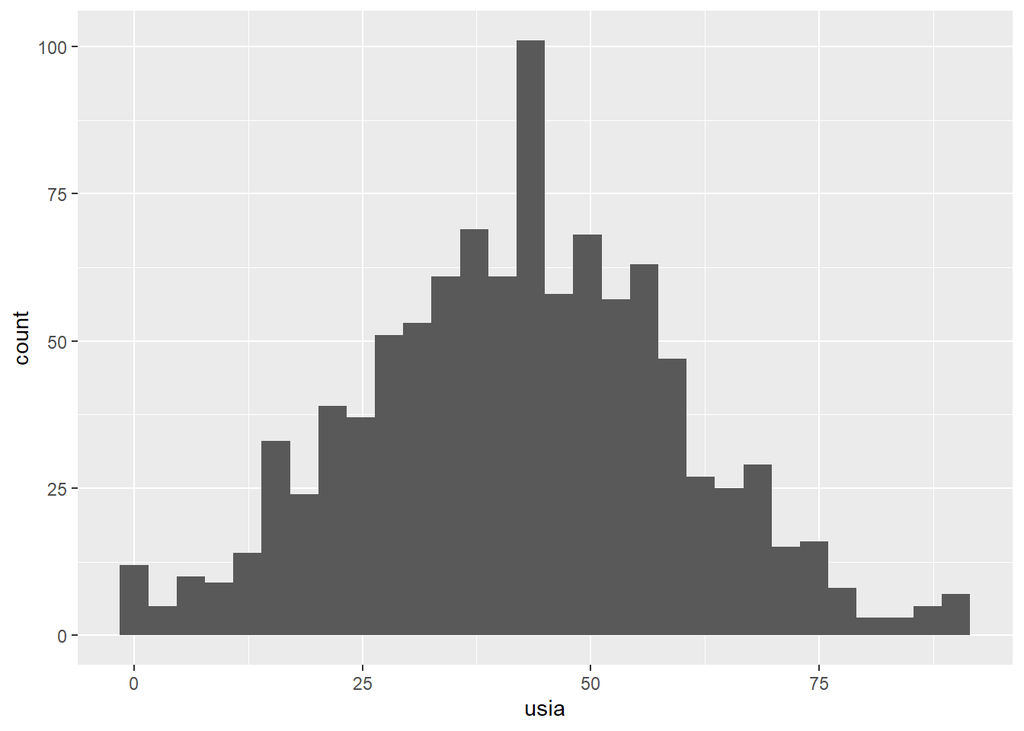

```r
ggplot(data, aes(x = usia)) +
  geom_histogram()
```

Histogram membantu melihat:

- pusat distribusi;
- penyebaran;
- bentuk distribusi;
- kemungkinan skewness;
- area yang jarang memiliki observasi.

## 10.4 Mengatur Bin Histogram

Histogram membagi data ke dalam beberapa interval.

`bins` mengatur jumlah interval.

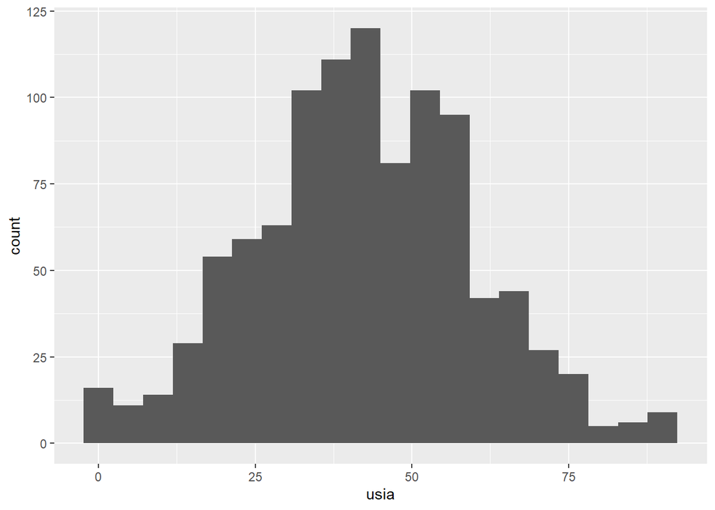

```r
ggplot(data, aes(x = usia)) +
  geom_histogram(bins = 20)
```

Bandingkan dengan:

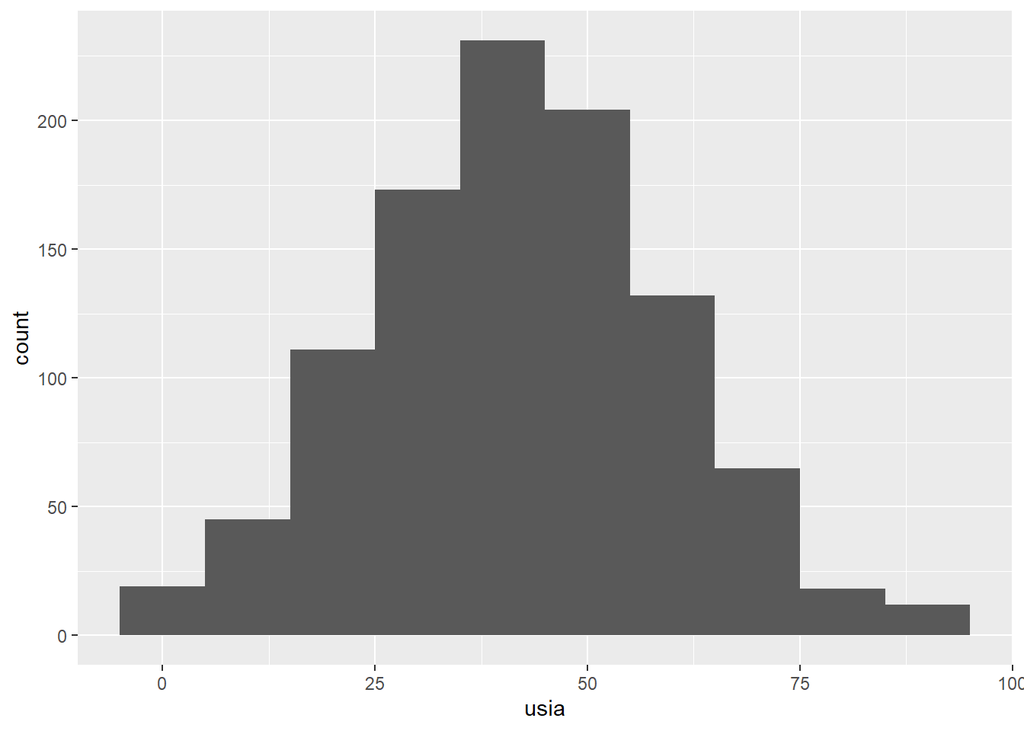

```r
ggplot(data, aes(x = usia)) +
  geom_histogram(bins = 10)
```

> Terlalu sedikit atau terlalu banyak bin dapat membuat pola distribusi sulit dibaca.

## 10.5 Histogram Biaya Klaim

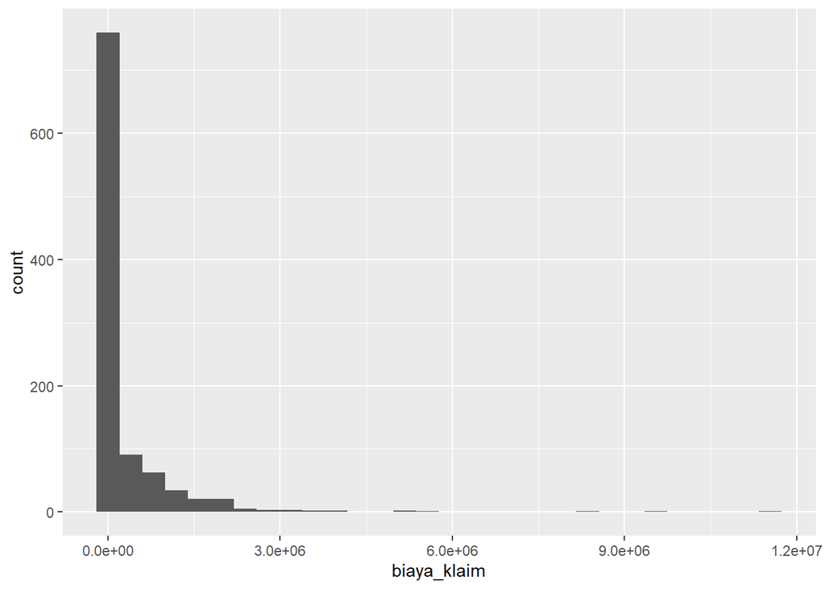

```r
ggplot(data, aes(x = biaya_klaim)) +
  geom_histogram(bins = 30)
```

Perhatikan apakah biaya klaim:

- terkonsentrasi pada nilai rendah;
- memiliki ekor ke kanan;
- memiliki beberapa nilai yang sangat besar.

### Latihan 10.1

Buat histogram untuk:

1. `usia`;
2. `jumlah_kunjungan`;
3. `jumlah_klaim`;
4. `biaya_klaim`.

Untuk setiap grafik, tuliskan satu atau dua temuan utama.

## 10.6 Boxplot

### Apa fungsi `geom_boxplot()`?

`geom_boxplot()` membuat boxplot yang membantu melihat:

- median;
- Q1;
- Q3;
- IQR;
- nilai yang berada jauh dari pusat distribusi.

```r
ggplot(data, aes(y = biaya_klaim)) +
  geom_boxplot()
```

[output not shown]

Boxplot sangat berguna untuk data biaya karena biaya sering memiliki distribusi yang tidak simetris.

## 10.7 Membaca Boxplot

Secara sederhana:

- garis tengah kotak → median;
- bagian bawah kotak → Q1;
- bagian atas kotak → Q3;
- tinggi kotak → IQR;
- titik di luar whisker → kandidat outlier.

> **Penting:** titik di luar whisker adalah kandidat outlier, bukan otomatis kesalahan data.

## 10.8 Bar Chart

### Apa fungsi `geom_bar()`?

`geom_bar()` menghitung jumlah observasi pada setiap kategori dan membuat bar chart.

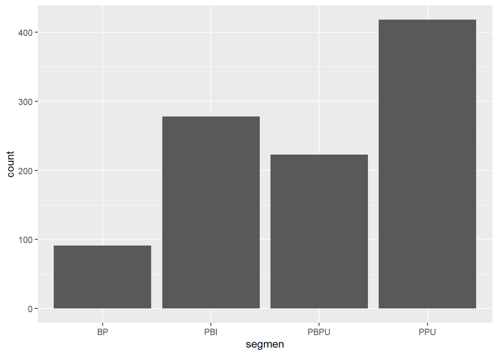

```r
ggplot(data, aes(x = segmen)) +
  geom_bar()
```

Untuk provinsi:

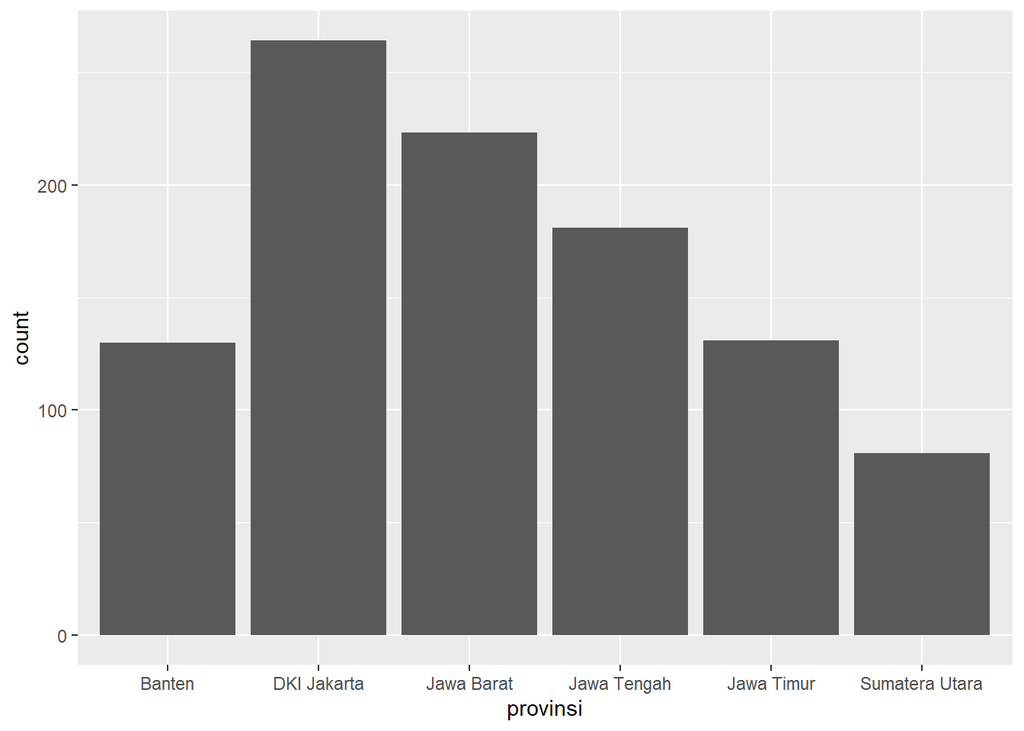

```r
ggplot(data, aes(x = provinsi)) +
  geom_bar()
```

Jika nama kategori panjang, grafik dapat dibuat horizontal:

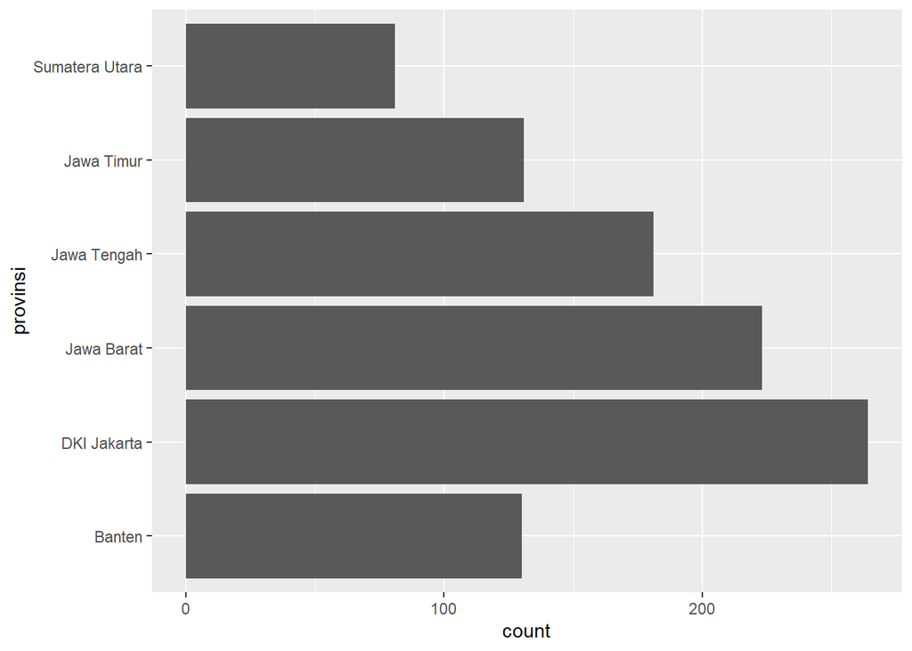

```r
ggplot(data, aes(x = provinsi)) +
  geom_bar() +
  coord_flip()
```

### Apa fungsi `coord_flip()`?

`coord_flip()` menukar orientasi sumbu sehingga kategori tampil secara horizontal.

## 10.9 Latihan 10.2 — Memilih Output yang Tepat

Untuk masing-masing pertanyaan, tentukan apakah lebih tepat menggunakan:

- `summary()`;
- frequency;
- histogram;
- boxplot;
- bar chart.

### Pertanyaan

1. Berapa median biaya klaim?
2. Bagaimana distribusi usia?
3. Berapa peserta pada setiap segmen?
4. Apakah biaya klaim memiliki nilai ekstrem?
5. Berapa Q1 dan Q3 jumlah kunjungan?

Setelah memilih metode, jalankan analisisnya.

# 11. EDA Bivariate

## 11.1 Apa Itu Bivariate EDA?

Bivariate EDA mengeksplorasi **dua variabel**.

Pertanyaan utamanya:

> **Apakah terdapat keterkaitan atau perbedaan antara dua variabel?**

Metode yang dipilih bergantung pada tipe kedua variabel.

| Tipe Variabel | Metode |
| --- | --- |
| Numeric × Numeric | scatter plot, correlation |
| Categorical × Numeric | group summary, boxplot |
| Categorical × Categorical | crosstab, percentage, bar chart |

## 11.2 Numeric × Numeric: Scatter Plot

### Apa fungsi `geom_point()`?

`geom_point()` menampilkan titik observasi.

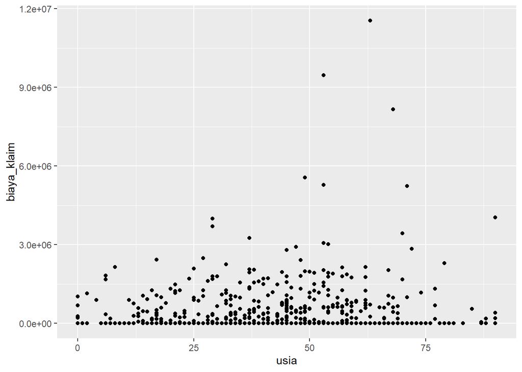

```r
ggplot(data, aes(x = usia, y = biaya_klaim)) +
  geom_point()
```

Scatter plot digunakan untuk melihat:

- arah hubungan;
- pola hubungan;
- kekuatan pola secara visual;
- kemungkinan kelompok;
- nilai ekstrem.

## 11.3 Menambahkan Garis Tren

### Apa fungsi `geom_smooth()`?

`geom_smooth()` menambahkan garis yang membantu melihat pola umum hubungan.

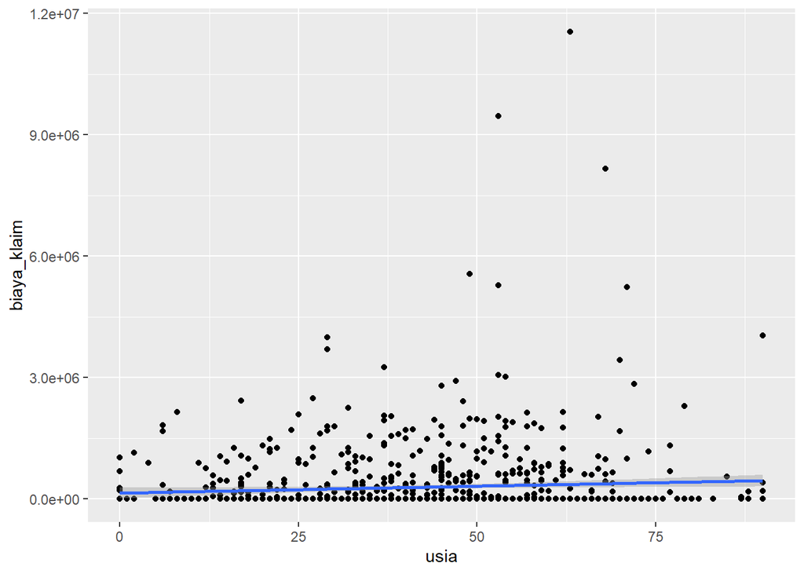

```r
ggplot(data, aes(x = usia, y = biaya_klaim)) +
  geom_point() +
  geom_smooth(method = "lm")
```

`method = "lm"` menggunakan linear model untuk menggambarkan tren linear.

> Garis tren membantu visualisasi. Jangan langsung menganggap hubungan linear berarti hubungan sebab-akibat.

## 11.4 Correlation

### Apa fungsi `cor()`?

`cor()` menghitung korelasi antara dua variabel numerik.

```r
cor(data$usia, data$biaya_klaim)
```

```
## [1] 0.07325635
```

Jika ada missing value, dapat digunakan:

```r
cor(
  data$usia,
  data$biaya_klaim,
  use = "complete.obs"
)
```

```
## [1] 0.07325635
```

Secara umum:

- mendekati +1 → hubungan linear positif kuat;
- mendekati -1 → hubungan linear negatif kuat;
- mendekati 0 → hubungan linear lemah/tidak terlihat.

> Korelasi mengukur **asosiasi linear**, bukan kausalitas.

## 11.5 Latihan 11.1

Analisis hubungan:

> `usia` dan `biaya_klaim`

Lakukan:

1. scatter plot;
2. scatter plot + garis tren;
3. correlation;
4. interpretasi.

Gunakan format:

> **Finding:** …

> **Interpretation:** …

> **Implication:** …

## 11.6 Categorical × Numeric

Pertanyaan:

> Apakah biaya klaim berbeda menurut segmen?

Langkah pertama: buat ringkasan per segmen.

```r
data %>%
  group_by(segmen) %>%
  summarise(
    n = n(),
    mean_biaya = mean(biaya_klaim),
    median_biaya = median(biaya_klaim)
  )
```

```
## # A tibble: 4 × 4
##   segmen     n mean_biaya median_biaya
##   <chr>  <int>      <dbl>        <dbl>
## 1 BP        91    189374.            0
## 2 PBI      278    291381.            0
## 3 PBPU     223    303430.            0
## 4 PPU      418    310923.            0
```

Kemudian gunakan boxplot.

```r
ggplot(data, aes(x = segmen, y = biaya_klaim)) +
  geom_boxplot()
```

[output not shown]

### Mengapa menggunakan mean dan median?

Karena keduanya memberikan informasi berbeda:

- mean → rata-rata;
- median → nilai tengah;
- perbedaan besar antara mean dan median dapat mengindikasikan skewness atau pengaruh nilai ekstrem.

## 11.7 Categorical × Categorical

Pertanyaan:

> Apakah status rawat inap berbeda menurut segmen?

Mulai dari crosstab:

```r
table(data$segmen, data$rawat_inap)
```

```
##
##          0   1
##   BP    87   4
##   PBI  265  13
##   PBPU 210  13
##   PPU  390  28
```

Kemudian lihat persentase per baris:

```r
prop.table(
  table(data$segmen, data$rawat_inap),
  margin = 1
)
```

```
##
##                 0          1
##   BP   0.95604396 0.04395604
##   PBI  0.95323741 0.04676259
##   PBPU 0.94170404 0.05829596
##   PPU  0.93301435 0.06698565
```

Visualisasi dapat menggunakan bar chart.

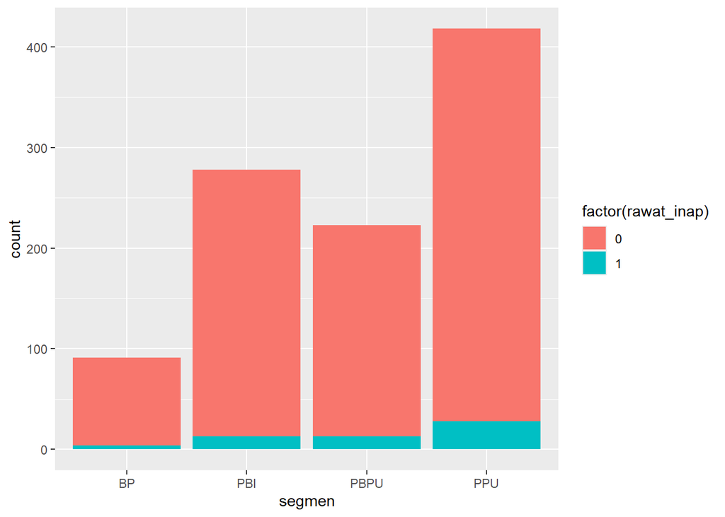

```r
ggplot(data, aes(x = segmen, fill = factor(rawat_inap))) +
  geom_bar()
```

`fill` digunakan untuk membedakan kategori di dalam grafik.

## 11.8 Latihan 11.2

Analisis tiga pasangan berikut:

### A. Numeric × Numeric

`jumlah_kunjungan` dan `jumlah_klaim`

### B. Categorical × Numeric

`faskes_tingkat` dan `biaya_klaim`

### C. Categorical × Categorical

`segmen` dan `rawat_inap`

Untuk setiap pasangan:

1. pilih metode;
2. jalankan analisis;
3. temukan pola;
4. tuliskan interpretasi.

# 12. EDA Berdasarkan Kelompok

## 12.1 Mengapa Group Comparison?

Kadang nilai rata-rata seluruh populasi tidak cukup.

Misalnya:

> Rata-rata biaya klaim seluruh peserta = RpX.

Pertanyaan berikutnya:

> Apakah biaya tersebut sama untuk semua provinsi?

Karena itu kita perlu melakukan **group comparison**.

## 12.2 `group_by()`

### Apa fungsi `group_by()`?

`group_by()` memberi tahu R bahwa analisis berikutnya harus dilakukan **per kelompok**.

Contoh:

```r
data %>%
  group_by(provinsi)
```

```
## # A tibble: 1,010 × 15
## # Groups:   provinsi [6]
##    id_peserta  usia jenis_kelamin segmen provinsi faskes_tingkat penyakit_kronis
##    <chr>      <int> <chr>         <chr>  <chr>    <chr>                    <int>
##  1 P00001        32 P             PBI    Jawa Ti… Puskesmas                    1
##  2 P00002         8 P             PPU    Jawa Te… Klinik                       0
##  3 P00003        15 P             PPU    DKI Jak… RS Tipe C                    0
##  4 P00004        58 P             PPU    Jawa Ti… RS Tipe B                    1
##  5 P00005        37 L             PPU    DKI Jak… RS Tipe B                    0
##  6 P00006        58 P             PPU    Jawa Te… Puskesmas                    1
##  7 P00007        38 P             PBI    Jawa Ba… Klinik                       0
##  8 P00008        42 P             PPU    Banten   Klinik                       1
##  9 P00009        61 P             PPU    Jawa Ti… RS Tipe C                    0
## 10 P00010        49 L             BP     Jawa Ba… Puskesmas                    0
## # ℹ 1,000 more rows
## # ℹ 8 more variables: rawat_inap <int>, hari_rawat_inap <int>,
## #   jumlah_kunjungan <int>, jumlah_klaim <int>, biaya_klaim <int>,
## #   exposure_bulan <int>, tanggal_masuk <chr>, tanggal_keluar <chr>
```

Biasanya `group_by()` digunakan bersama `summarise()`.

## 12.3 Mean per Kelompok

```r
data %>%
  group_by(provinsi) %>%
  summarise(
    mean_biaya = mean(biaya_klaim)
  )
```

```
## # A tibble: 6 × 2
##   provinsi       mean_biaya
##   <chr>               <dbl>
## 1 Banten            346131.
## 2 DKI Jakarta       237167.
## 3 Jawa Barat        272682.
## 4 Jawa Tengah       379773.
## 5 Jawa Timur        267763.
## 6 Sumatera Utara    291790.
```

Tambahkan jumlah observasi:

```r
data %>%
  group_by(provinsi) %>%
  summarise(
    n = n(),
    mean_biaya = mean(biaya_klaim)
  )
```

```
## # A tibble: 6 × 3
##   provinsi           n mean_biaya
##   <chr>          <int>      <dbl>
## 1 Banten           130    346131.
## 2 DKI Jakarta      264    237167.
## 3 Jawa Barat       223    272682.
## 4 Jawa Tengah      181    379773.
## 5 Jawa Timur       131    267763.
## 6 Sumatera Utara    81    291790.
```

### Kenapa `n` penting?

Perbedaan rata-rata perlu dibaca bersama ukuran kelompok.

Kelompok dengan jumlah observasi sangat sedikit dapat menghasilkan rata-rata yang kurang stabil.

## 12.4 Mean vs Median per Kelompok

```r
data %>%
  group_by(provinsi) %>%
  summarise(
    mean_biaya = mean(biaya_klaim),
    median_biaya = median(biaya_klaim)
  )
```

```
## # A tibble: 6 × 3
##   provinsi       mean_biaya median_biaya
##   <chr>               <dbl>        <dbl>
## 1 Banten            346131.            0
## 2 DKI Jakarta       237167.            0
## 3 Jawa Barat        272682.            0
## 4 Jawa Tengah       379773.            0
## 5 Jawa Timur        267763.            0
## 6 Sumatera Utara    291790.            0
```

Jika mean jauh lebih tinggi daripada median pada suatu kelompok, periksa distribusi dan nilai ekstrem kelompok tersebut.

## 12.5 Mengurutkan Kelompok

Gunakan `arrange()` untuk melihat kelompok dengan nilai terbesar.

```r
data %>%
  group_by(provinsi) %>%
  summarise(
    mean_biaya = mean(biaya_klaim)
  ) %>%
  arrange(desc(mean_biaya))
```

```
## # A tibble: 6 × 2
##   provinsi       mean_biaya
##   <chr>               <dbl>
## 1 Jawa Tengah       379773.
## 2 Banten            346131.
## 3 Sumatera Utara    291790.
## 4 Jawa Barat        272682.
## 5 Jawa Timur        267763.
## 6 DKI Jakarta       237167.
```

## 12.6 Grouped Boxplot

Untuk membandingkan distribusi biaya antarprovinsi:

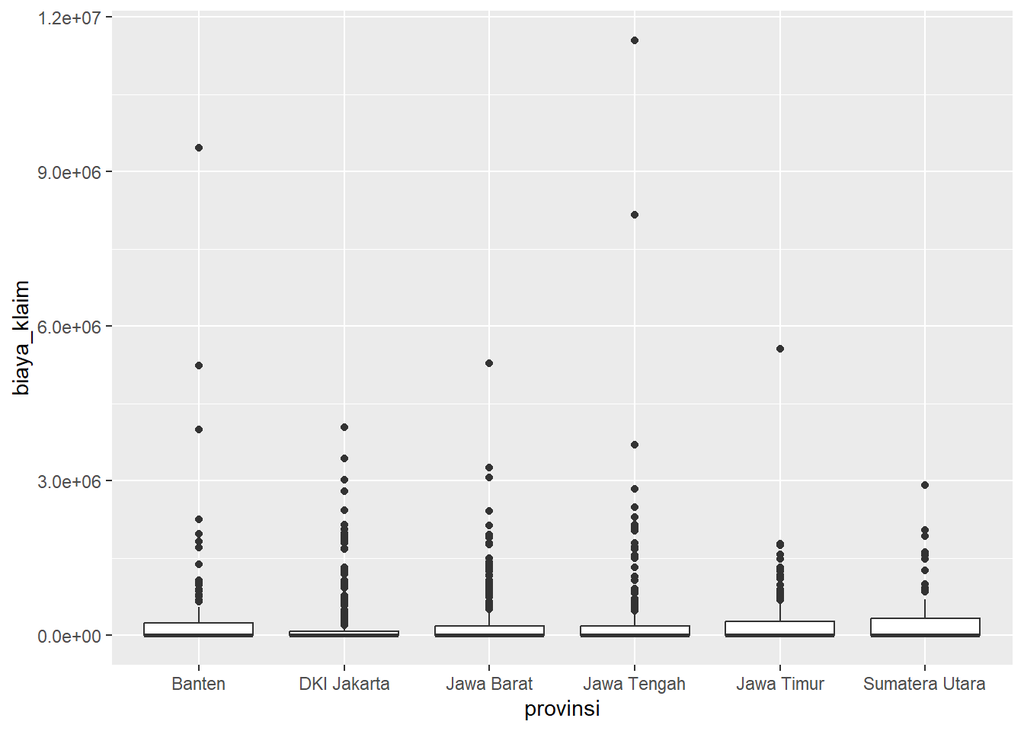

```r
ggplot(data, aes(x = provinsi, y = biaya_klaim)) +
  geom_boxplot()
```

Jika kategori terlalu panjang:

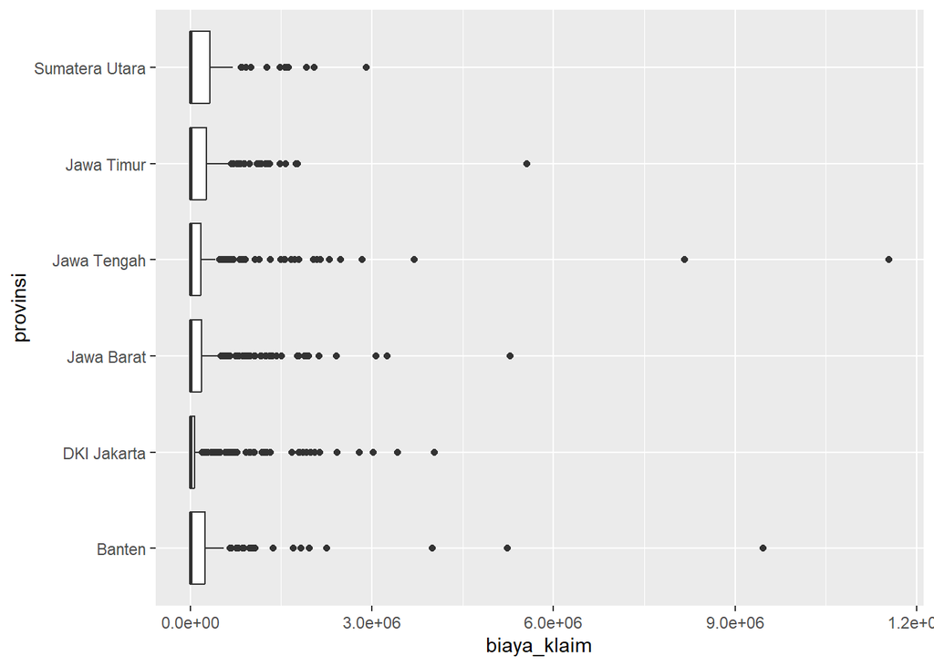

```r
ggplot(data, aes(x = provinsi, y = biaya_klaim)) +
  geom_boxplot() +
  coord_flip()
```

### Apa yang dibandingkan?

Jangan hanya melihat median.

Perhatikan:

- posisi median;
- lebar/tinggi IQR;
- panjang whisker;
- kandidat outlier;
- bentuk distribusi antar kelompok.

## 12.7 Group Comparison Berdasarkan Segmen

```r
data %>%
  group_by(segmen) %>%
  summarise(
    n = n(),
    mean_biaya = mean(biaya_klaim),
    median_biaya = median(biaya_klaim)
  )
```

```
## # A tibble: 4 × 4
##   segmen     n mean_biaya median_biaya
##   <chr>  <int>      <dbl>        <dbl>
## 1 BP        91    189374.            0
## 2 PBI      278    291381.            0
## 3 PBPU     223    303430.            0
## 4 PPU      418    310923.            0
```

Visualisasikan:

```r
ggplot(data, aes(x = segmen, y = biaya_klaim)) +
  geom_boxplot()
```

[output not shown]

## 12.8 Latihan 12.1

Bandingkan biaya klaim berdasarkan:

1. `provinsi`;
2. `segmen`;
3. `faskes_tingkat`.

Untuk setiap kelompok, hitung:

- `n`;
- mean;
- median.

Kemudian buat boxplot.

Jawab:

1. Kelompok mana yang memiliki mean terbesar?
2. Apakah kelompok dengan mean terbesar juga memiliki median terbesar?
3. Apakah terdapat kelompok dengan mean jauh di atas median?
4. Apakah distribusi antar kelompok terlihat berbeda?

# 13. Outlier & Extreme Value

## 13.1 Apa Itu Outlier?

**Outlier** adalah observasi yang berada jauh dari sebagian besar observasi lainnya menurut suatu kriteria statistik.

Namun:

> **Outlier tidak otomatis berarti data salah.**

Sebuah biaya klaim yang sangat besar dapat:

- merupakan kesalahan input;
- merupakan duplikasi;
- merupakan kasus medis yang memang berat;
- merupakan kejadian langka tetapi benar-benar terjadi.

Karena itu outlier harus **diinvestigasi**.

## 13.2 Outlier vs Invalid Value

Perbedaan penting:

### Invalid value

Nilai melanggar aturan atau tidak masuk akal.

Contoh:

- usia = -5;
- jumlah klaim = -2;
- biaya klaim = -100.000.

### Extreme value

Nilai masih mungkin benar, tetapi sangat jauh dari sebagian besar observasi.

Contoh:

- mayoritas biaya klaim < Rp5 juta;
- satu klaim = Rp100 juta.

Nilai Rp100 juta **belum tentu salah**.

## 13.3 IQR

Metode umum untuk mendeteksi kandidat outlier adalah **IQR method**.

IQR:

$$IQR = Q3 - Q1$$

Batas bawah:

$$Q1 - 1.5(IQR)$$

Batas atas:

$$Q3 + 1.5(IQR)$$

Observasi di luar batas tersebut disebut **kandidat outlier**.

## 13.4 Menghitung Q1

Gunakan `quantile()`.

```r
Q1 <- quantile(data$biaya_klaim, 0.25)
```

## 13.5 Menghitung Q3

```r
Q3 <- quantile(data$biaya_klaim, 0.75)
```

## 13.6 Menghitung IQR

```r
IQR_value <- Q3 - Q1
```

## 13.7 Menghitung Batas Bawah

```r
lower <- Q1 - 1.5 * IQR_value
```

## 13.8 Menghitung Batas Atas

```r
upper <- Q3 + 1.5 * IQR_value
```

Lihat batasnya:

```r
lower
```

```
##     25%
## -287625
```

```r
upper
```

```
##    75%
## 479375
```

## 13.9 Mencari Kandidat Outlier

### Apa fungsi `filter()`?

`filter()` memilih baris yang memenuhi kondisi tertentu.

Cari biaya di atas batas atas:

```r
data %>%
  filter(biaya_klaim > upper)
```

```
##     id_peserta usia jenis_kelamin segmen       provinsi faskes_tingkat
## 1       P00003   15             P    PPU    DKI Jakarta      RS Tipe C
## 2       P00005   37             L    PPU    DKI Jakarta      RS Tipe B
## 3       P00012   74             P    PPU     Jawa Timur         Klinik
## 4       P00014   30             P    PPU         Banten      Puskesmas
## 5       P00029   27             P    PBI     Jawa Timur      RS Tipe C
## 6       P00032   63             P    PPU    Jawa Tengah      Puskesmas
## 7       P00038   62             L   PBPU     Jawa Barat      RS Tipe B
## 8       P00044   54             L    PPU    DKI Jakarta      Puskesmas
## 9       P00055   62             P    PPU     Jawa Barat      Puskesmas
## 10      P00060   50             L    PPU     Jawa Barat         Klinik
## 11      P00069   59             L    PPU         Banten      RS Tipe B
## 12      P00071   33             P    PBI     Jawa Barat      RS Tipe A
## 13      P00077   62             L     BP     Jawa Barat         Klinik
## 14      P00079   49             L   PBPU    DKI Jakarta      Puskesmas
```

[output cut: 531 more lines]

Hitung jumlahnya:

```r
data %>%
  filter(biaya_klaim > upper) %>%
  nrow()
```

```
## [1] 181
```

Cari nilai di bawah batas bawah:

```r
data %>%
  filter(biaya_klaim < lower)
```

```
##  [1] id_peserta       usia             jenis_kelamin    segmen
##  [5] provinsi         faskes_tingkat   penyakit_kronis  rawat_inap
##  [9] hari_rawat_inap  jumlah_kunjungan jumlah_klaim     biaya_klaim
## [13] exposure_bulan   tanggal_masuk    tanggal_keluar
## <0 rows> (or 0-length row.names)
```

## 13.10 Melihat Outlier dengan Boxplot

```r
ggplot(data, aes(y = biaya_klaim)) +
  geom_boxplot()
```

[output not shown]

Gunakan boxplot untuk membantu melihat kandidat nilai ekstrem secara visual.

## 13.11 Bagaimana Menentukan Treatment?

Jangan langsung menghapus outlier.

Gunakan lima kemungkinan keputusan:

### 1. Retain

Dipertahankan jika nilai ekstrem masih valid dan relevan.

Contoh:

> Klaim sangat besar, tetapi setelah pemeriksaan dokumen ternyata benar.

### 2. Investigate

Perlu diperiksa lebih lanjut jika belum jelas apakah nilai benar.

### 3. Correct

Diperbaiki jika terbukti terjadi kesalahan input dan nilai yang benar diketahui.

### 4. Transform

Transformasi dapat dipertimbangkan jika distribusi sangat skewed dan kebutuhan analisis mendukung.

### 5. Remove

Dihapus jika terbukti merupakan error/duplikasi dan tidak layak digunakan untuk analisis.

> **Kriteria keputusan harus dijelaskan. Jangan menulis “dihapus karena outlier”.**

## 13.12 Latihan 13.1

Deteksi kandidat outlier pada:

1. `biaya_klaim`;
2. `jumlah_kunjungan`;
3. `jumlah_klaim`.

Untuk setiap variabel:

1. hitung Q1;
2. hitung Q3;
3. hitung IQR;
4. tentukan batas bawah;
5. tentukan batas atas;
6. identifikasi kandidat outlier;
7. buat boxplot;
8. tentukan apakah perlu retain, investigate, correct, transform, atau remove.

### Pertanyaan penting

> Apakah semua kandidat outlier harus dihapus?

Jawaban yang diharapkan:

> Tidak. Status outlier hanya menunjukkan bahwa observasi tersebut ekstrem menurut kriteria statistik. Keputusan treatment harus mempertimbangkan validitas data dan konteks bisnis.

# 14. Communicating EDA

## 14.1 Mengapa Komunikasi Penting?

Analisis yang baik bukan hanya:

```
mean = ...
median = ...
correlation = ...
```

Klien membutuhkan jawaban:

> **“Jadi apa yang bisa kita pahami dari hasil ini?”**

Karena itu, setiap output perlu diterjemahkan menjadi informasi yang mudah dipahami.

## 14.2 Finding → Interpretation → Implication

Gunakan tiga langkah.

### Finding

Apa yang terlihat pada data?

Contoh:

> Median biaya klaim lebih rendah daripada mean biaya klaim.

### Interpretation

Apa arti pola tersebut?

> Perbedaan tersebut menunjukkan distribusi biaya klaim cenderung tidak simetris dan terdapat observasi dengan biaya relatif tinggi.

### Implication

Apa artinya bagi analisis atau bisnis?

> Untuk analisis biaya, median perlu dipertimbangkan bersama mean agar gambaran pusat distribusi tidak hanya dipengaruhi oleh klaim bernilai sangat tinggi.

## 14.3 Jangan Overclaim

Hindari:

> “Usia menyebabkan biaya klaim meningkat.”

Jika kita hanya melakukan scatter plot dan correlation, kita belum membuktikan sebab-akibat.

Lebih tepat:

> “Pada data ini terlihat kecenderungan hubungan antara usia dan biaya klaim, namun analisis ini tidak membuktikan hubungan kausal.”

## 14.4 Memilih Grafik Berdasarkan Pertanyaan

| Pertanyaan | Output |
| --- | --- |
| Bagaimana distribusi usia? | Histogram |
| Apakah biaya memiliki nilai ekstrem? | Boxplot |
| Berapa jumlah peserta per segmen? | Bar chart |
| Apakah usia dan biaya berkaitan? | Scatter plot + correlation |
| Apakah biaya berbeda antarsegmen? | Group summary + boxplot |
| Bagaimana rawat inap menurut segmen? | Crosstab + percentage/bar chart |

### Prinsip

> **Pertanyaan → tipe variabel → metode → output → interpretasi**

## 14.5 Menulis Kesimpulan Singkat

Gunakan pola:

> **Finding:** apa yang ditemukan?

> **Interpretation:** apa artinya?

> **Implication:** mengapa hal tersebut penting?

Contoh:

> **Finding:** Rata-rata biaya klaim lebih tinggi daripada median biaya klaim.

> **Interpretation:** Hal ini menunjukkan adanya ketidaksimetrisan distribusi dan kemungkinan pengaruh beberapa klaim bernilai tinggi.

> **Implication:** Analisis biaya sebaiknya mempertimbangkan median dan distribusi, bukan hanya mean.

## 14.6 Latihan 14.1 — Communicating EDA

Pilih satu hasil dari analisis sebelumnya.

Tulis:

1. **Finding**
2. **Interpretation**
3. **Implication**

Batasi jawaban menjadi 3–5 kalimat.

Kemudian jawab:

> Jika Anda menjelaskan hasil tersebut kepada klien yang tidak memahami statistik, bagaimana Anda menyederhanakan penjelasannya?

# 15. Integrated Practice

## 15.1 Simulasi Tugas Data Analytics PAI

Pada bagian ini kita menggabungkan seluruh proses menjadi satu alur.

Alur yang perlu dikuasai:

**Cleaning → Validation → Missing → Duplicate → Consistency → Descriptive Statistics → EDA → Interpretation**

Dataset yang tersedia untuk hands-on ini adalah `data_clean.csv`, sehingga data sudah berada dalam kondisi yang siap digunakan untuk EDA.

Dalam konteks simulasi, peserta tetap perlu memahami bahwa sebelum analisis dilakukan, analyst harus memastikan data layak digunakan.

## 15.2 Tahap 1 — Load Data

```r
data <- read.csv("data_clean.csv")
```

Cek ukuran:

```r
dim(data)
```

```
## [1] 1010   15
```

Cek struktur:

```r
str(data)
```

```
## 'data.frame':    1010 obs. of  15 variables:
##  $ id_peserta      : chr  "P00001" "P00002" "P00003" "P00004" ...
##  $ usia            : int  32 8 15 58 37 58 38 42 61 49 ...
##  $ jenis_kelamin   : chr  "P" "P" "P" "P" ...
##  $ segmen          : chr  "PBI" "PPU" "PPU" "PPU" ...
##  $ provinsi        : chr  "Jawa Timur" "Jawa Tengah" "DKI Jakarta" "Jawa Timur" ...
##  $ faskes_tingkat  : chr  "Puskesmas" "Klinik" "RS Tipe C" "RS Tipe B" ...
##  $ penyakit_kronis : int  1 0 0 1 0 1 0 1 0 0 ...
##  $ rawat_inap      : int  0 0 0 0 0 0 0 0 0 0 ...
##  $ hari_rawat_inap : int  0 0 0 0 0 0 0 0 0 0 ...
##  $ jumlah_kunjungan: int  2 1 3 4 4 2 1 0 0 0 ...
##  $ jumlah_klaim    : int  0 0 2 2 4 1 0 0 0 0 ...
##  $ biaya_klaim     : int  0 0 919000 121000 2060000 34000 0 0 0 0 ...
##  $ exposure_bulan  : int  12 12 12 12 12 12 12 12 12 12 ...
##  $ tanggal_masuk   : chr  "2025-03-13 00:00:00" "2025-09-29 00:00:00" "2025-08-04 00:00:00" "2025-08-13 00:00:00" ...
##  $ tanggal_keluar  : chr  "2025-03-13 00:00:00" "2025-09-29 00:00:00" "2025-08-04 00:00:00" "2025-08-13 00:00:00" ...
```

## 15.3 Tahap 2 — Validation

Meskipun data sudah dibersihkan, lakukan pengecekan dasar.

Cek usia:

```r
summary(data$usia)
```

```
##    Min. 1st Qu.  Median    Mean 3rd Qu.    Max.
##    0.00   31.00   42.50   42.37   54.00   90.00
```

Cek biaya:

```r
summary(data$biaya_klaim)
```

```
##     Min.  1st Qu.   Median     Mean  3rd Qu.     Max.
##        0        0        0   292939   191750 11539000
```

Cek kategori segmen:

```r
table(data$segmen)
```

```
##
##   BP  PBI PBPU  PPU
##   91  278  223  418
```

Cek provinsi:

```r
table(data$provinsi)
```

```
##
##         Banten    DKI Jakarta     Jawa Barat    Jawa Tengah     Jawa Timur
##            130            264            223            181            131
## Sumatera Utara
##             81
```

### Pertanyaan

Apakah terdapat nilai yang:

- tidak masuk akal?
- sangat ekstrem?
- berada di luar kategori yang diharapkan?

Jangan hanya melihat hasil. Jelaskan keputusan Anda.

## 15.4 Tahap 3 — Missing

### Apa fungsi `is.na()`?

`is.na()` digunakan untuk mengecek apakah suatu nilai adalah missing.

```r
sum(is.na(data))
```

```
## [1] 0
```

Untuk satu variabel:

```r
sum(is.na(data$biaya_klaim))
```

```
## [1] 0
```

Jika hasilnya 0, berarti tidak ada missing pada variabel tersebut.

## 15.5 Tahap 4 — Duplicate

### Apa fungsi `duplicated()`?

`duplicated()` mengidentifikasi baris yang merupakan duplikasi dari baris sebelumnya.

```r
sum(duplicated(data))
```

```
## [1] 0
```

Jika hasilnya 0, tidak ditemukan exact duplicate berdasarkan seluruh kolom.

## 15.6 Tahap 5 — Consistency

Gunakan aturan bisnis sederhana.

Contoh:

> Jika `jumlah_klaim = 0`, biaya klaim seharusnya tidak bernilai positif.

Gunakan `filter()` untuk mencari kondisi tersebut.

```r
data %>%
  filter(jumlah_klaim == 0, biaya_klaim > 0)
```

```
##  [1] id_peserta       usia             jenis_kelamin    segmen
##  [5] provinsi         faskes_tingkat   penyakit_kronis  rawat_inap
##  [9] hari_rawat_inap  jumlah_kunjungan jumlah_klaim     biaya_klaim
## [13] exposure_bulan   tanggal_masuk    tanggal_keluar
## <0 rows> (or 0-length row.names)
```

Untuk rawat inap:

> Jika `rawat_inap = 0`, `hari_rawat_inap` seharusnya 0.

```r
data %>%
  filter(rawat_inap == 0, hari_rawat_inap > 0)
```

```
##  [1] id_peserta       usia             jenis_kelamin    segmen
##  [5] provinsi         faskes_tingkat   penyakit_kronis  rawat_inap
##  [9] hari_rawat_inap  jumlah_kunjungan jumlah_klaim     biaya_klaim
## [13] exposure_bulan   tanggal_masuk    tanggal_keluar
## <0 rows> (or 0-length row.names)
```

### Pertanyaan

Jika ditemukan baris yang melanggar aturan, apakah langsung dihapus?

Jawab dengan mempertimbangkan:

1. apakah benar error?
2. apakah ada sumber data untuk verifikasi?
3. apakah nilai masih dapat diperbaiki?
4. apa dampaknya terhadap analisis?

## 15.7 Tahap 6 — Descriptive Statistics

Buat ringkasan untuk:

- `usia`;
- `jumlah_kunjungan`;
- `jumlah_klaim`;
- `biaya_klaim`.

Minimal laporkan:

- mean;
- median;
- min;
- max;
- Q1;
- Q3;
- SD.

Contoh:

```r
data %>%
  summarise(
    mean_usia = mean(usia),
    median_usia = median(usia)
  )
```

```
##   mean_usia median_usia
## 1  42.36634        42.5
```

Kemudian buat ringkasan untuk biaya:

```r
data %>%
  summarise(
    mean_biaya = mean(biaya_klaim),
    median_biaya = median(biaya_klaim)
  )
```

```
##   mean_biaya median_biaya
## 1   292938.6            0
```

## 15.8 Tahap 7 — Frequency & Crosstab

Buat frequency:

```r
data %>%
  count(segmen)
```

```
##   segmen   n
## 1     BP  91
## 2    PBI 278
## 3   PBPU 223
## 4    PPU 418
```

Buat percentage:

```r
prop.table(table(data$segmen)) * 100
```

```
##
##        BP       PBI      PBPU       PPU
##  9.009901 27.524752 22.079208 41.386139
```

Buat crosstab:

```r
table(data$segmen, data$rawat_inap)
```

```
##
##          0   1
##   BP    87   4
##   PBI  265  13
##   PBPU 210  13
##   PPU  390  28
```

Buat row percentage:

```r
prop.table(
  table(data$segmen, data$rawat_inap),
  margin = 1
) * 100
```

```
##
##                0         1
##   BP   95.604396  4.395604
##   PBI  95.323741  4.676259
##   PBPU 94.170404  5.829596
##   PPU  93.301435  6.698565
```

## 15.9 Tahap 8 — Univariate EDA

Buat histogram usia:

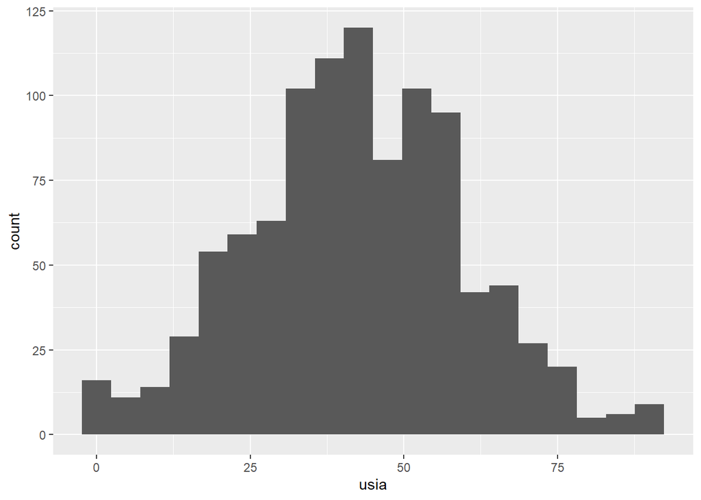

```r
ggplot(data, aes(x = usia)) +
  geom_histogram(bins = 20)
```

Buat boxplot biaya:

```r
ggplot(data, aes(y = biaya_klaim)) +
  geom_boxplot()
```

[output not shown]

Buat bar chart segmen:

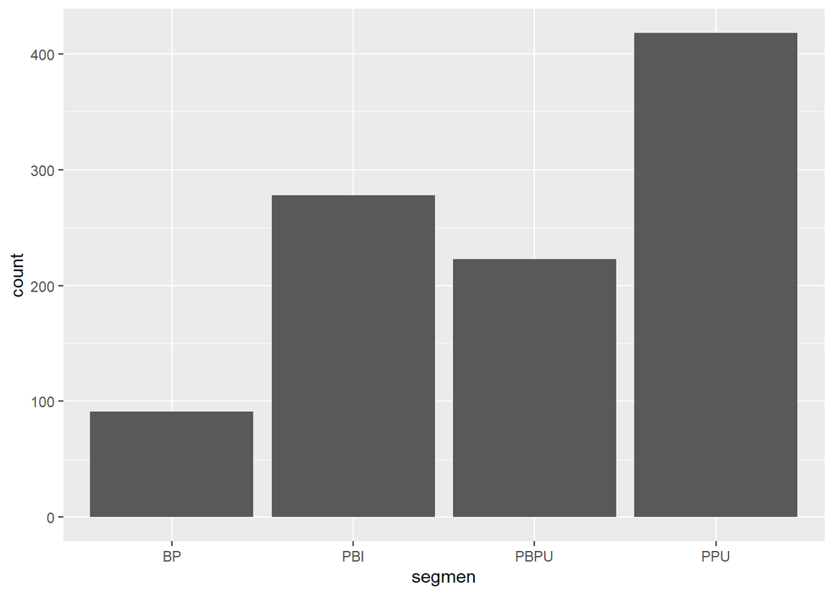

```r
ggplot(data, aes(x = segmen)) +
  geom_bar()
```

Tuliskan minimal satu finding dari setiap grafik.

## 15.10 Tahap 9 — Bivariate EDA

### Pertanyaan 1

Apakah usia dan biaya klaim memiliki keterkaitan?

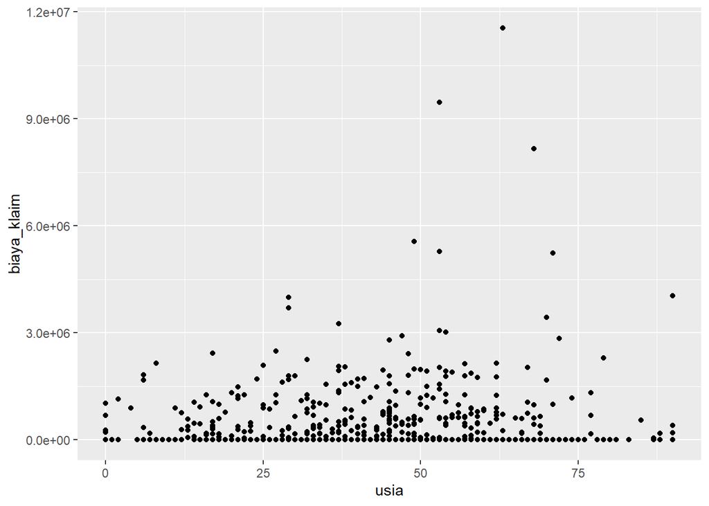

```r
ggplot(data, aes(x = usia, y = biaya_klaim)) +
  geom_point()
```

Hitung correlation:

```r
cor(
  data$usia,
  data$biaya_klaim
)
```

```
## [1] 0.07325635
```

### Pertanyaan 2

Apakah biaya klaim berbeda menurut segmen?

```r
data %>%
  group_by(segmen) %>%
  summarise(
    mean_biaya = mean(biaya_klaim),
    median_biaya = median(biaya_klaim)
  )
```

```
## # A tibble: 4 × 3
##   segmen mean_biaya median_biaya
##   <chr>       <dbl>        <dbl>
## 1 BP        189374.            0
## 2 PBI       291381.            0
## 3 PBPU      303430.            0
## 4 PPU       310923.            0
```

Visualisasikan:

```r
ggplot(data, aes(x = segmen, y = biaya_klaim)) +
  geom_boxplot()
```

[output not shown]

### Pertanyaan 3

Bagaimana rawat inap menurut segmen?

```r
table(data$segmen, data$rawat_inap)
```

```
##
##          0   1
##   BP    87   4
##   PBI  265  13
##   PBPU 210  13
##   PPU  390  28
```

## 15.11 Tahap 10 — Outlier

Gunakan biaya klaim.

```r
Q1 <- quantile(data$biaya_klaim, 0.25)
```

```r
Q3 <- quantile(data$biaya_klaim, 0.75)
```

```r
IQR_value <- Q3 - Q1
```

```r
upper <- Q3 + 1.5 * IQR_value
```

Cari kandidat:

```r
data %>%
  filter(biaya_klaim > upper)
```

```
##     id_peserta usia jenis_kelamin segmen       provinsi faskes_tingkat
## 1       P00003   15             P    PPU    DKI Jakarta      RS Tipe C
## 2       P00005   37             L    PPU    DKI Jakarta      RS Tipe B
## 3       P00012   74             P    PPU     Jawa Timur         Klinik
## 4       P00014   30             P    PPU         Banten      Puskesmas
## 5       P00029   27             P    PBI     Jawa Timur      RS Tipe C
## 6       P00032   63             P    PPU    Jawa Tengah      Puskesmas
## 7       P00038   62             L   PBPU     Jawa Barat      RS Tipe B
## 8       P00044   54             L    PPU    DKI Jakarta      Puskesmas
## 9       P00055   62             P    PPU     Jawa Barat      Puskesmas
## 10      P00060   50             L    PPU     Jawa Barat         Klinik
## 11      P00069   59             L    PPU         Banten      RS Tipe B
## 12      P00071   33             P    PBI     Jawa Barat      RS Tipe A
## 13      P00077   62             L     BP     Jawa Barat         Klinik
## 14      P00079   49             L   PBPU    DKI Jakarta      Puskesmas
```

[output cut: 531 more lines]

Kemudian jawab:

> Apakah kandidat tersebut harus dihapus?

Gunakan konsep:

**retain / investigate / correct / transform / remove**

## 15.12 Tahap 11 — Final Interpretation

Buat ringkasan akhir maksimal 5–7 kalimat.

Gunakan struktur:

### Finding 1

Temuan utama dari descriptive statistics.

### Finding 2

Temuan utama dari frequency/crosstab.

### Finding 3

Temuan utama dari univariate EDA.

### Finding 4

Temuan utama dari bivariate/group comparison.

### Finding 5

Temuan utama dari outlier analysis.

### Implication

Jelaskan apa arti temuan tersebut untuk analisis atau pengambilan keputusan.

# PAI-Oriented Practice

## Soal Simulasi

Anda diminta melakukan eksplorasi data peserta JKN untuk membantu tim analitik memahami pola pemanfaatan layanan dan biaya klaim.

### Tugas

**A. Descriptive Statistics**

Buat ringkasan numerik `biaya_klaim`.

Jelaskan:

- pusat data;
- sebaran;
- rentang;
- kemungkinan skewness.

**B. Frequency**

Buat frequency dan percentage `segmen`.

Jelaskan distribusi peserta.

**C. Crosstab**

Analisis `segmen × rawat_inap`.

Gunakan frequency dan row percentage.

**D. Univariate**

Buat:

- histogram `biaya_klaim`;
- boxplot `biaya_klaim`;
- bar chart `segmen`.

Jelaskan karakteristik data.

**E. Bivariate**

Analisis:

- `usia × biaya_klaim`;
- `segmen × biaya_klaim`;
- `segmen × rawat_inap`.

Pilih metode yang sesuai untuk masing-masing pasangan.

**F. Outlier**

Gunakan metode IQR untuk `biaya_klaim`.

Jelaskan apakah kandidat outlier sebaiknya:

- retain;
- investigate;
- correct;
- transform;
- remove.

**G. Communication**

Tuliskan kesimpulan menggunakan:

> **Finding → Interpretation → Implication**

# Checklist EDA

Sebelum menyatakan analisis selesai, pastikan:

- Struktur data sudah dipahami.
- Tipe setiap variabel sudah dikenali.
- Statistik yang digunakan sesuai tipe data.
- Mean dan median sudah dibandingkan jika relevan.
- Frequency dan proportion sudah diperiksa untuk data kategorikal.
- Crosstab digunakan untuk dua variabel kategorikal.
- Histogram digunakan untuk melihat distribusi numerik.
- Boxplot digunakan untuk melihat sebaran dan kandidat outlier.
- Scatter plot digunakan untuk numeric × numeric.
- Correlation digunakan jika relevan.
- Group summary digunakan untuk membandingkan kelompok.
- Outlier tidak langsung dianggap sebagai error.
- Setiap outlier sudah dipertimbangkan treatment-nya.
- Finding sudah diterjemahkan menjadi interpretation.
- Interpretation sudah dikaitkan dengan implication.
- Tidak membuat klaim kausal hanya dari EDA.

# Ringkasan Fungsi R yang Perlu Dikuasai

## Base R

| Fungsi | Kegunaan |
| --- | --- |
| `read.csv()` | membaca CSV |
| `head()` | melihat baris awal |
| `dim()` | melihat ukuran data |
| `names()` | melihat nama variabel |
| `str()` | melihat struktur dan tipe data |
| `summary()` | ringkasan statistik umum |
| `mean()` | rata-rata |
| `median()` | median |
| `min()` | minimum |
| `max()` | maksimum |
| `quantile()` | kuantil/Q1/Q3 |
| `sd()` | standard deviation |
| `range()` | rentang min–max |
| `table()` | frequency/crosstab |
| `prop.table()` | proporsi/persentase |
| `cor()` | korelasi |
| `is.na()` | mengecek missing |
| `duplicated()` | mengecek duplicate |

## `dplyr`

| Fungsi | Kegunaan |
| --- | --- |
| `filter()` | memilih baris berdasarkan kondisi |
| `select()` | memilih kolom |
| `count()` | menghitung frequency |
| `group_by()` | membuat analisis per kelompok |
| `summarise()` | membuat ringkasan |
| `arrange()` | mengurutkan hasil |
| `n()` | menghitung jumlah observasi |

## `ggplot2`

| Fungsi | Kegunaan |
| --- | --- |
| `ggplot()` | memulai grafik |
| `aes()` | menentukan mapping variabel |
| `geom_histogram()` | histogram |
| `geom_boxplot()` | boxplot |
| `geom_bar()` | bar chart |
| `geom_point()` | scatter plot |
| `geom_smooth()` | garis/tren |
| `coord_flip()` | membalik orientasi grafik |

# Pola Berpikir Ujian PAI

Saat mendapatkan soal EDA, jangan langsung mengetik kode.

Gunakan urutan:

**1. Apa pertanyaannya?**

↓

**2. Variabel apa yang digunakan?**

↓

**3. Tipe datanya apa?**

↓

**4. Statistik/grafik apa yang sesuai?**

↓

**5. Apa yang ditunjukkan output?**

↓

**6. Apa interpretasinya?**

↓

**7. Apa implikasinya?**

Contoh:

> **Pertanyaan:** Apakah biaya klaim berbeda antarsegmen?

→ Variabel `segmen` = categorical

→ Variabel `biaya_klaim` = numeric

→ Gunakan group summary + boxplot

→ Bandingkan mean dan median

→ Periksa distribusi

→ Identifikasi kemungkinan outlier

→ Tulis finding → interpretation → implication.

# Penutup

EDA bukan sekadar membuat tabel dan grafik.

Tujuan akhirnya adalah memahami:

> **“Apa yang sedang terjadi pada data, kelompok mana yang berbeda, pola apa yang terlihat, dan apa arti temuan tersebut?”**

Untuk ujian Data Analytics PAI, biasakan menjawab dengan tiga lapisan:

**Output → Interpretation → Business Meaning**

Karena analyst yang baik bukan hanya dapat menghitung statistik, tetapi dapat menjelaskan **cerita di balik data** dengan jelas dan bertanggung jawab.